# Dirichlet Process Mixtures: Sensitivity to the precision parameter

Joon-Ho Lee (joonho@berkeley.edu)

March 10, 2020

# 1 The Rubin (1981) model with Dirichlet Process prior

## 1.1 The classic Rubin (1981) model

Consider $K$ study sites in which researchers perform the same interventions and measure the same outcomes. Each site, indexed by $k$, estimates a treatment effect $\tau_k$ averaged across individuals in the site. The sites don’t report $\{\tau_k\}^{K}_{k=1}$: instead, they report $\{\hat{\tau}_k\}^{K}_{k=1}$. Some of the observed variation in $\{\hat{\tau}_k\}^{K}_{k=1}$ is sampling variation, yet there is likely to be some genuine variation in effects across settings, often defined as $\sigma_{\tau}^{2} = \text{var}(\tau_{k})$.

Rubin (1981) considers a case in which the analyst has access to a set of estimated effects $\{\hat{\tau}_k\}^{K}_{k=1}$ and estimates of the associated sampling errors $\{\hat{se}_{\tau_k}\}^{K}_{k=1}$. Rubin specifies a relationship between the observed estimates and the unobserved $\{\tau_k\}^{K}_{k=1}$, and in addition specifies a relationship between $\{\tau_k\}^{K}_{k=1}$ and the aggregate parameters $(\tau, \sigma_{\tau}^2)$). The Rubin (1981) model has a hierarchical likelihood in which each site has own treatment effect parameter, $\tau_k$, but these effects are all drawn from a common distribution governed by $(\tau, \sigma_{\tau}^2)$ as follows:

$$\hat{\tau}_{k} \sim N(\tau_{k}, \hat{se}_{k}^2) \quad \forall k,$$
$$\tau_{k} \sim N(\tau, \sigma_{\tau}^2) \quad \forall k.$$

## 1.2 Semiparametric modeling via Dirichlet Process[^1]

The Rubin (1981) model is fully parametric and a particular case of a more general class of models on the prior distribution $G$. In the Rubin (1981) model, inferences may depend on the assumed forms for higher level priors (e.g., $\tau, \sigma_{\tau}^2$), and will be distorted if there are unrecognized features such as multiple modes in the underlying second-level effects. Instead of assuming a known prior distribution for $G$ for second-level latent effects, the **Dirichlet Process (DP)** prior involves a distribution on $G$ itself, acknowledging uncertainty about its form.

The DP prior involves (1) a base distribution $G_{0}$, the expectation of $G$, and (2) a precision or strength parameter $\alpha_0$ governing the concentration of the prior for $G$ about its mean $G_{0}$. For any partition $A_1, ..., A_M$ on the support of $G_0$, the vector $\{G(A_1), ..., G(A_M)\}$ of probabilities $G(A_m)$ contained in the set $\{A_m, m = 1, ..., M\}$ follows a Dirichlet distribution $\text{Dirichlet}(\alpha_0 \cdot G_0(A_1), ..., \alpha_0 \cdot G_0(A_M))$.[^2]

Original forms of the DP prior assumed $G_0$ to be known and fixed. One problem with a Dirichlet Process when $G_0$ is known is that it assigns a probability of 1 to the space of discrete probablity measures, which means that site-level treatment effects $\{\hat{\tau}_k\}^{K}_{k=1}$ are measured exactly. An alternative is to take the parameters in $G_0$ to be unknown, and to follow a set of parametric distributions, with possibly unknown hyperparametrees, resulting in a mixture of Dirichlet Process (MDP) model:

$$\hat{\tau}_{k} \sim N(\tau_{k}, \hat{se}_{k}^2) \quad \forall k,$$
$$\tau_{k} \sim \text{DP}(G_0, \alpha_0) \quad \forall k,$$

where $G_0 = N(\tau, \sigma_{\tau}^{2})$, $\tau \sim N(0, 100)$, and $\sigma_{\tau}^{-2} \sim \text{Gamma}(1, 1)$.

## 1.3 The goal of this document

The precision parameter $\alpha$ can be considered as random, having a gamma distribution, $\alpha_0 \sim \text{Gamma}(4, 4)$, or fixed at some particular value. In this document, we vary the fixed value of $\alpha$ and examine the sensitivity of posterior inferences to the $\alpha$. We show that the model with DP prior becomes the model with Gaussian prior if the base distribution $G_{0}$ is Gaussian and the precision parameter $\alpha_0$ is fixed at a large value.

# 2 Generate a simulated dataset

$G$ will be simulated to follow a mixture of two Gaussian homoscedastic components, $0.8N(0, 1) + 0.2N(4, 1)$, that is normalized to have mean 0 and variance 1.

```r
### Generate sample draws from the mixture model
set.seed(12345)

df_G <- GenerateMdp(n = 50, rgt = 1, rsr = 5)[c(1:3)] %>%
  data.frame() %>%
  rownames_to_column("K") %>%
  mutate_at(.vars = c("K"), .funs = as.numeric)

head(df_G)
```

```
##   K      tau_k  tau_k_hat     se_k2
## 1 1 -1.2822414 -1.6438915 0.2000000
## 2 2  1.3624897  1.8251537 0.2135794
## 3 3 -0.3204998 -0.1026991 0.2280808
## 4 4 -0.8514422 -1.5592805 0.2435668
## 5 5  2.1366106  2.0013040 0.2601043
## 6 6  1.7517588  2.0899928 0.2777646
```

# 3 Parameter estimation using the Dirichlet process prior

```r
### Set initial state (the current value of the parameters)
state <- NULL

### Set MCMC parameters
nburn <- 4000    # the number of burn-in scans
nsave <- 4000    # the total number of scans to be saved
nskip <- 20      # the thinning interval
ndisplay <- 100  # the number of saved scans to be displayed on screen

mcmc <- list(nburn = nburn, nsave = nsave,
             nskip = nskip, ndisplay = ndisplay)

### Prepare dataset as a matrix form (with y and sigma2)
mat_DPmeta <- df_G %>% select(tau_k_hat, se_k2) %>% as.matrix()

### A loop over fixed alpha
alpha_vec <- c(0.1, 1, 100)
list_collect <- list()

for (i in seq_along(alpha_vec)){

  ## Set prior parameters
  prior <- list(alpha = alpha_vec[i],  # fixed precision parameter
                tau1 = 1,             # G0 variance: shape param.
                tau2 = 1,             # G0 variance: rate param.
                mub = 0,
                Sb = 100)             # G0 mean: mean

  ## Estimate the Dirichlet Process model using DPpackage
  outp_DPmeta <- DPmeta(formula = mat_DPmeta ~ 1,
                        prior = prior, mcmc = mcmc,
                        state = state, status = TRUE)

  ## Save as a list element
  list_collect[[i]] <- outp_DPmeta
}

### Define a function to tidy up the DPmeta objects
get_posterior_DPmeta <- function(outp = outp_DPmeta, nburn = 4000){

  # (1) Tidy up the "theta" output object
  df_theta <- outp$save.state$randsave %>%
    data.frame() %>%
    dplyr::select(-Prediction) %>%
    slice(c((nburn/2 + 1):nburn))  # throw away burn-ins
  colnames(df_theta) <- paste0("tau_k[", seq(ncol(df_theta)), "]")

  # (2) Tidy up the G0 parameters (m, s2), alpha0, and N of clusters outputs
  df_hyperparm <- outp$save.state$thetasave %>%
    data.frame() %>%
    dplyr::select(-tau_k_hat) %>%
    rename(G0_mu = mu, G0_s2 = sigma2, Ncluster = ncluster, alpha0 = alpha) %>%
    dplyr::select(G0_mu, G0_s2, alpha0, Ncluster) %>%
    slice(c((nburn/2 + 1):nburn))  # throw away burn-ins

  # Return the resulting object
  cbind.data.frame(df_hyperparm, df_theta)
}

### Collect posterior samples per each alpha setting
list_df <- list()
for (i in seq_along(alpha_vec)){
  list_df[[i]] <- get_posterior_DPmeta(list_collect[[i]], nburn)
}

df_collect <- bind_rows(list_df) %>%
  mutate(alpha0 = as.character(alpha0))
```

# 4 Parameter estimation using the Gaussian prior

Next, we obtain simulates from the posterior of a Gaussian model using **Stan**. We aim to verify that we get a solution that is very similar to just assuming a Gaussian distribution if we fix $\alpha$ to a large value instead of giving it a prior.

```
data {
  int<lower = 0> K;         // number of sites
  real tau_hat_k[K];        // estimated treatment effects
  real<lower=0> se_k[K];    // s.e. of effect estimates
}
parameters {
  real tau;
  real<lower=0> sigma_tau2;
  real tau_k[K];
}
transformed parameters {
  real<lower=0> sigma_tau;
  sigma_tau = sqrt(sigma_tau2);
}
model {
  sigma_tau2 ~ inv_gamma(1, 1);     // vague prior
  tau ~ normal(0, 100);             // vague prior
  tau_k ~ normal(tau, sigma_tau);   // second-level normal
  tau_hat_k ~ normal(tau_k, se_k);  // third-level normal
}
generated quantities{
  real predicted_tau_k;
  predicted_tau_k = normal_rng(tau, sigma_tau);  //mixed predictive
}
```

Note that we impose a gamma prior on the inverse variance components $\sigma_{\tau}^{-2}$ even though serious problems can result if the number of second stage units(i.e., sites) is small and/or the variance are near zero (Gelman and others 2006). We opt for the gamma prior in order to allow the comparison with DP prior models because the `DPmeta` function assumes the inverse gamma distribution for the prior distribution of the variance of the base distribution $G_{0}$.

```r
### Collect data into a list format suitable for Stan
stan_data <- list(K = length(df_G$K),
                  tau_hat_k = df_G$tau_k_hat,
                  se_k = sqrt(df_G$se_k2))

### Compile and run the stan model
fit_norm <- stan(file = "rubin_model_Gaussian_Invgamma prior.stan",
                 data = stan_data,
                 iter = 1000, chains = 4)
```

```r
print(fit_norm, probs = c(0.1, 0.5, 0.9), digits = 3)
```

```
## Inference for Stan model: rubin_model_Gaussian_Invgamma prior.
## 4 chains, each with iter=1000; warmup=500; thin=1;
## post-warmup draws per chain=500, total post-warmup draws=2000.
##
##                    mean se_mean    sd     10%     50%     90% n_eff  Rhat
## tau               0.088   0.005 0.212  -0.186   0.087   0.354  1767 1.000
## sigma_tau2        1.238   0.012 0.386   0.797   1.176   1.751  1121 1.002
## tau_k[1]         -1.395   0.008 0.423  -1.929  -1.409  -0.852  2917 0.999
## tau_k[2]          1.556   0.008 0.446   0.982   1.545   2.124  2918 0.999
## tau_k[3]         -0.074   0.008 0.436  -0.620  -0.079   0.494  2868 0.999
## tau_k[4]         -1.272   0.009 0.471  -1.879  -1.274  -0.671  2704 0.998
## tau_k[5]          1.660   0.009 0.477   1.042   1.655   2.252  2947 0.999
## tau_k[6]          1.700   0.009 0.497   1.060   1.703   2.323  3161 1.000
## tau_k[7]          0.213   0.010 0.475  -0.408   0.199   0.827  2330 1.001
## tau_k[8]         -0.653   0.010 0.507  -1.295  -0.643  -0.004  2468 1.000
## tau_k[9]         -0.633   0.010 0.526  -1.291  -0.634   0.033  2769 1.000
## tau_k[10]        -1.092   0.010 0.503  -1.726  -1.088  -0.462  2396 1.000
## tau_k[11]         2.015   0.013 0.549   1.315   2.002   2.718  1672 1.000
## tau_k[12]         1.545   0.010 0.551   0.837   1.537   2.276  2779 1.000
## tau_k[13]         1.070   0.010 0.567   0.354   1.075   1.794  2966 1.000
## tau_k[14]         1.754   0.011 0.614   0.977   1.742   2.531  3105 0.999
## tau_k[15]         0.100   0.010 0.608  -0.671   0.107   0.876  3411 0.999
## tau_k[16]        -0.451   0.011 0.623  -1.273  -0.460   0.359  3171 0.999
## tau_k[17]         0.008   0.011 0.616  -0.788   0.013   0.803  3081 0.998
## tau_k[18]        -0.418   0.011 0.667  -1.272  -0.420   0.410  3398 0.999
## tau_k[19]        -0.213   0.012 0.628  -1.001  -0.214   0.583  2886 0.999
## tau_k[20]        -0.583   0.013 0.690  -1.458  -0.577   0.293  2728 1.000
## tau_k[21]        -0.489   0.012 0.679  -1.359  -0.498   0.373  3122 1.000
## tau_k[22]        -0.142   0.014 0.727  -1.049  -0.154   0.791  2743 0.999
## tau_k[23]         0.105   0.014 0.711  -0.819   0.096   1.050  2458 0.999
## tau_k[24]        -0.218   0.013 0.698  -1.134  -0.226   0.687  2892 1.000
## tau_k[25]        -0.543   0.014 0.746  -1.480  -0.556   0.416  2753 0.999
## tau_k[26]         0.548   0.015 0.764  -0.436   0.565   1.521  2760 0.999
## tau_k[27]         0.499   0.014 0.758  -0.450   0.495   1.459  2929 1.000
## tau_k[28]        -0.238   0.014 0.761  -1.224  -0.243   0.731  2849 0.999
## tau_k[29]        -0.625   0.015 0.802  -1.688  -0.607   0.421  3018 0.999
## tau_k[30]         1.118   0.016 0.855   0.039   1.083   2.210  2836 1.000
## tau_k[31]        -1.159   0.015 0.814  -2.212  -1.146  -0.131  2838 0.999
## tau_k[32]        -0.060   0.016 0.840  -1.124  -0.060   1.021  2838 1.000
## tau_k[33]        -0.683   0.016 0.884  -1.824  -0.660   0.424  3105 0.999
```

[output cut: 10 more lines]

```
## tau_k[44]         0.192   0.017 0.916  -0.929   0.167   1.366  3015 1.001
## tau_k[45]         0.016   0.016 0.977  -1.265   0.076   1.222  3761 0.999
## tau_k[46]         0.134   0.017 0.972  -1.074   0.111   1.374  3356 1.000
## tau_k[47]        -0.214   0.017 0.950  -1.424  -0.214   1.025  3091 0.999
## tau_k[48]        -0.337   0.018 0.983  -1.587  -0.318   0.938  3130 1.000
## tau_k[49]        -0.409   0.019 1.042  -1.764  -0.360   0.871  3077 0.999
## tau_k[50]         0.170   0.020 1.011  -1.121   0.156   1.443  2685 0.999
## sigma_tau         1.100   0.005 0.168   0.893   1.085   1.323  1105 1.002
## predicted_tau_k   0.062   0.025 1.119  -1.379   0.058   1.455  2015 1.002
## lp__            -51.685   0.264 6.468 -60.498 -51.273 -43.877   603 1.003
##
## Samples were drawn using NUTS(diag_e) at Tue Mar 10 16:26:21 2020.
## For each parameter, n_eff is a crude measure of effective sample size,
## and Rhat is the potential scale reduction factor on split chains (at
## convergence, Rhat=1).
```

# 5 Comparison of posterior samples

```r
### Extract posterior samples
df_norm <- as.data.frame(fit_norm) %>%
  mutate(alpha0 = "Gaussian") %>%
  rename(G0_mu = tau, G0_s2 = sigma_tau2) %>%
  dplyr::select(-sigma_tau, -predicted_tau_k, -lp__) %>%
  dplyr::select(G0_mu, G0_s2, alpha0, everything())

### Append to the results from DPpackage
df_combine <- bind_rows(list(df_norm, df_collect)) %>%
  mutate(alpha0 = factor(alpha0, levels = c("Gaussian", alpha_vec)))
```

## 5.1 Hyperparameters $\tau$ and $\sigma_{\tau}$

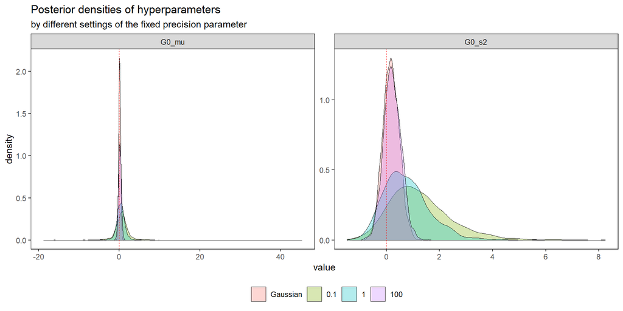

```r
### Generate a dataframe to plot
df_plot <- df_combine %>%
  dplyr::select(alpha0, G0_mu, G0_s2) %>%
  mutate(G0_s2 = log(G0_s2)) %>%    # Log-transformation for G0_s2
  gather(key = variable, value = value, -alpha0) %>%
  mutate(variable = factor(variable, levels = c("G0_mu", "G0_s2")))


### Define a function to generate plot
plot_compare_density <- function(df_plot, title = title, subtitle = subtitle){
  ggplot(data = df_plot, aes(x = value, group = alpha0, fill = alpha0)) +
    geom_density(position = "identity", size = 0.1, alpha = 0.3) +
    geom_vline(aes(xintercept = 0), size = 0.3, color = "red", linetype = "dashed") +
    labs(title = title, subtitle = subtitle) + theme_preset
}

### Plot
title <- c("Posterior densities of hyperparameters")
subtitle <- c("by different settings of the fixed precision parameter")
plot_compare_density(df_plot, title = title, subtitle = subtitle) +
  facet_wrap(~ variable, scales = "free")
```

## 5.2 The number of clusters

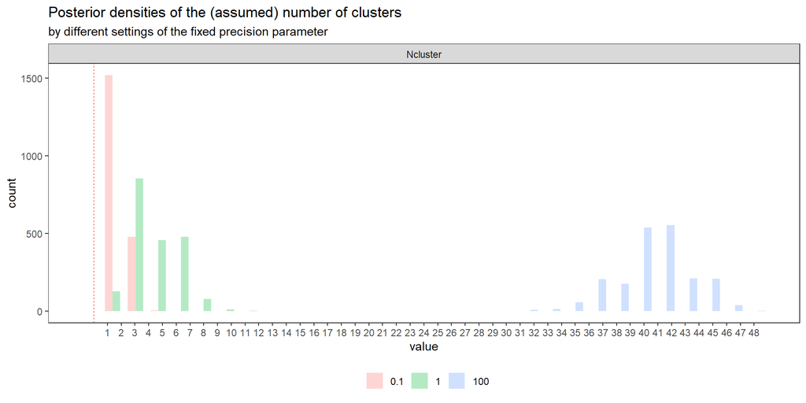

```r
### Generate a dataframe to plot
df_plot <- df_combine %>%
  dplyr::select(alpha0, Ncluster) %>%
  gather(key = variable, value = value, -alpha0) %>%
  drop_na()


### Define a function to generate plot
plot_compare_histogram <- function(df_plot, title = title, subtitle = subtitle){
  ggplot(data = df_plot, aes(x = value, group = alpha0, fill = alpha0)) +
    geom_histogram(position = "dodge", size = 1, alpha = 0.3) +
    geom_vline(aes(xintercept = 0), size = 0.3, color = "red", linetype = "dashed") +
    labs(title = title, subtitle = subtitle) + theme_preset
}

### Plot
title <- c("Posterior densities of the (assumed) number of clusters")
plot_compare_histogram(df_plot, title = title, subtitle = subtitle) +
  facet_wrap(~ variable, scales = "free") +
  scale_x_continuous(breaks = 1:max(df_plot$value, na.rm = TRUE))
```

## 5.3 Empirical distribution function (EDF) estimates for $\tau_{k}$s

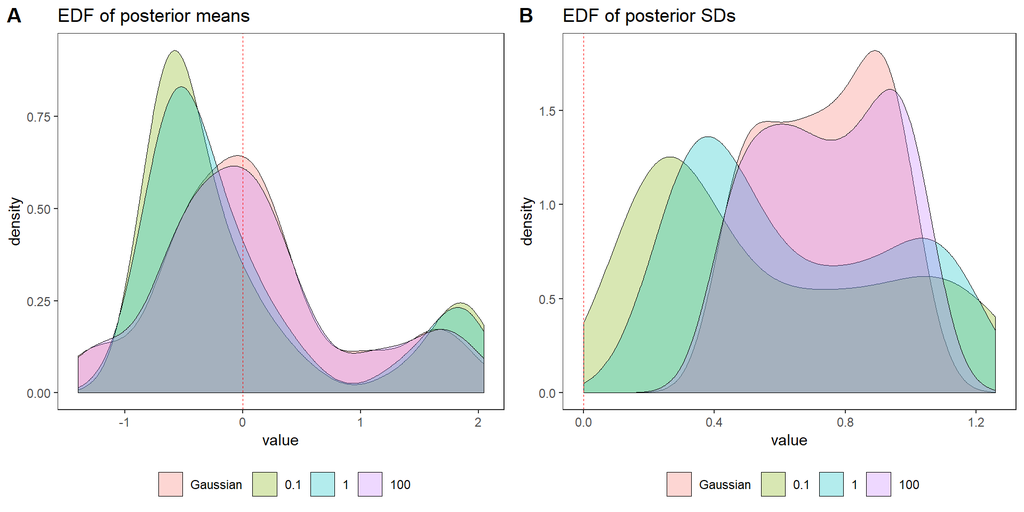

```r
### Generate a dataframe to plot
df_plot <- df_combine %>%
  dplyr::select(alpha0, contains("tau_k[")) %>%
  gather(key = variable, value = value, -alpha0) %>%
  group_by(alpha0, variable) %>%
  summarise(mean = mean(value, na.rm = TRUE),
            sd = sd(value, na.rm = TRUE)) %>%
  mutate(id = as.numeric(str_extract(variable, "\\d+"))) %>%
  arrange(id, alpha0)

### Plot
p1 <- plot_compare_density(df_plot %>% rename(value = mean),
                           title = "EDF of posterior means",
                           subtitle = NULL)

p2 <- plot_compare_density(df_plot %>% rename(value = sd),
                           title = "EDF of posterior SDs",
                           subtitle = NULL)

plot_grid(p1, p2, labels = "AUTO")
```

## 5.4 Site-specific individual effect estimates $\tau_{k}$s

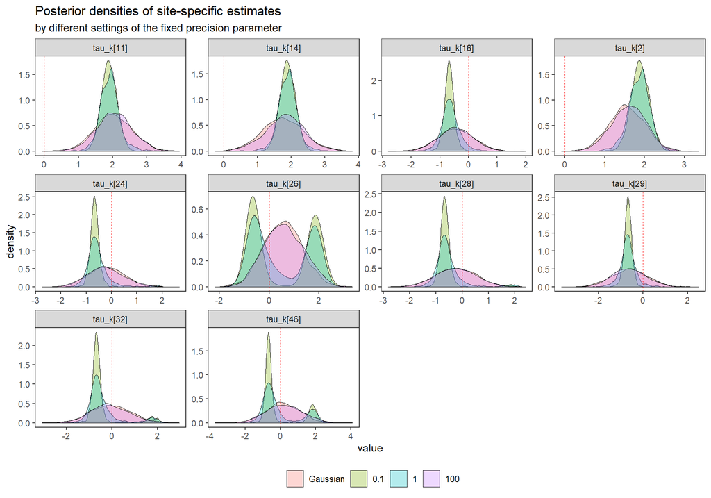

```r
### Randomly sample 10 sites
set.seed(12345)
rand_var <- paste0("tau_k[", sample(1:50, 10, replace = FALSE), "]")

### Generate a dataframe to plot
df_plot <- df_combine %>%
  dplyr::select(alpha0, rand_var) %>%
  gather(key = variable, value = value, -alpha0)

### Plot
title <- "Posterior densities of site-specific estimates"
plot_compare_density(df_plot, title = title, subtitle = subtitle) +
  facet_wrap(~ variable, scales = "free")
```

# References

Congdon, Peter D. 2019. *Bayesian Hierarchical Models: With Applications Using R*. CRC Press.

Gelman, Andrew, and others. 2006. “Prior Distributions for Variance Parameters in Hierarchical Models (Comment on Article by Browne and Draper).” *Bayesian Analysis* 1 (3): 515–34.

Rubin, Donald B. 1981. “Estimation in Parallel Randomized Experiments.” *Journal of Educational Statistics* 6 (4): 377–401.

[^1]: See Chapter 4.9 of Congdon (2019).
[^2]: Such an approach may be termed *semiparametric* as it involves a parametric model at the first level for the observations, but a nonparametric model at the second-level.